# Report for SPN01

[figure not shown]

This report shows the results for patient **SPN01** of SCOUT cohort. SPN01 is a prototype micro-satellite stable (MSS) colorectal cancer composed of 4 clones **SPN01** is profiled by 3 samples collected at 1 time-point.

[figure not shown]

# 1 Tissue Simulation and Sampling

This part of the report shows how the tumour growth in time. Muller plot and time series plot show changing in cellular growth of the different clones.

## 1.1 Tissue dynamics

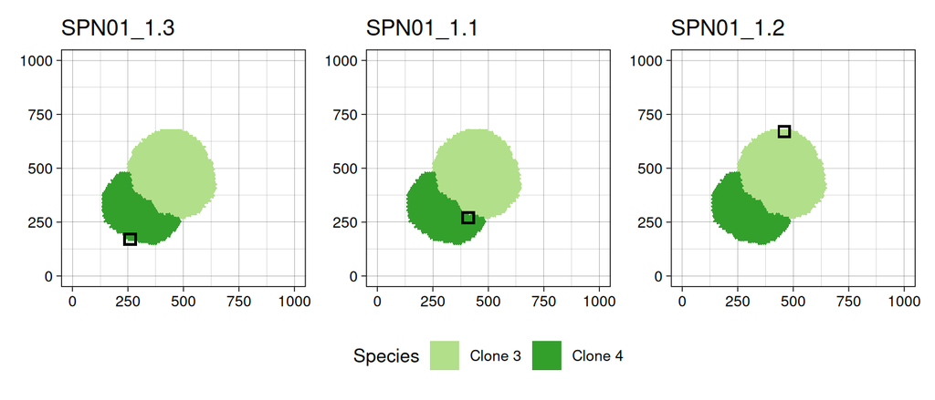

## 1.2 Sampling

SPN01 is sampled at 1 time-point, where a total of 3 samples are derived. Sampling dynamics is reported in the following plot:

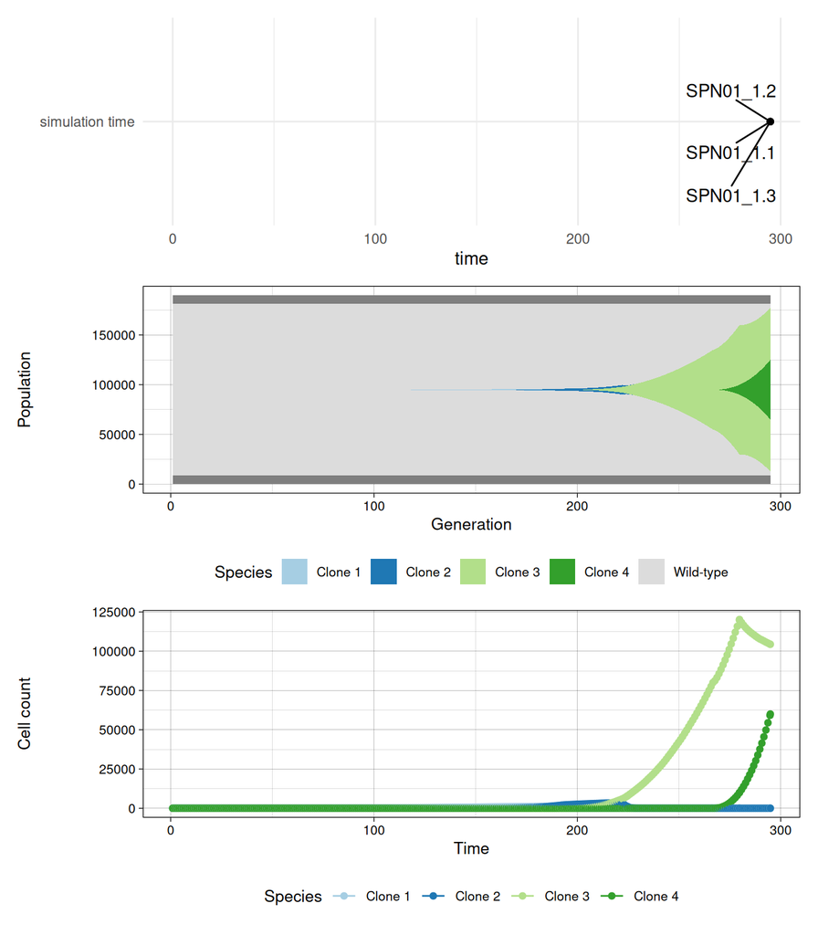

General information about the samples are reported in the table below.

| name | id | tumour_cells | tumour_cells_in_bbox | time | Clone 3 | Clone 4 | sample_type |
| --- | --- | --- | --- | --- | --- | --- | --- |
| SPN01_1.3 | 0 | 1169 | 1169 | 294.91 | 0 | 1169 | Monoclonal |
| SPN01_1.1 | 1 | 2473 | 2473 | 294.91 | 678 | 1795 | Polyclonal |
| SPN01_1.2 | 2 | 1265 | 1265 | 294.91 | 1265 | 0 | Monoclonal |

# 2 Mutation Engine

Mutational processes are added to the sampled cells based on the tumour type. In particular, the mutation engine is set up by specifing:

1. Mutation rates of SNVs, INDELs and CNAs;
2. Driver SNVs and CNAs;
3. SBS and ID mutational signatures.

## 2.2 Signature exposure

For SPN01 the following SBS and ID signatures are added to the simulated tumour:

| time | signature | exposure | type |
| --- | --- | --- | --- |
| 0 | SBS1 | 0.2 | SNV |
| 0 | SBS17b | 0.25 | SNV |
| 0 | SBS18 | 0.15 | SNV |
| 0 | SBS5 | 0.35 | SNV |
| 0 | SBS88 | 0.05 | SNV |
| 0 | ID1 | 0.6 | indel |
| 0 | ID2 | 0.4 | indel |

To visualize how signature exposure changes over time, a merged visualization is showed below:

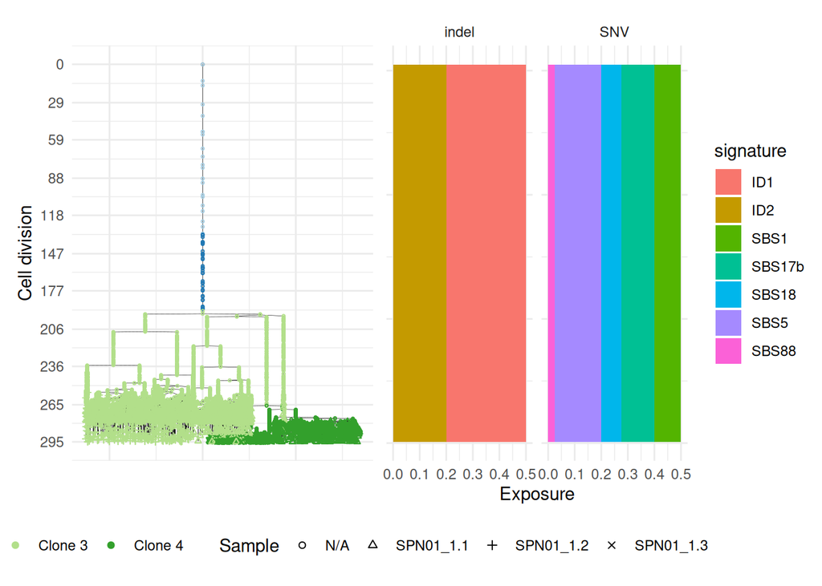

And in the muller plot:

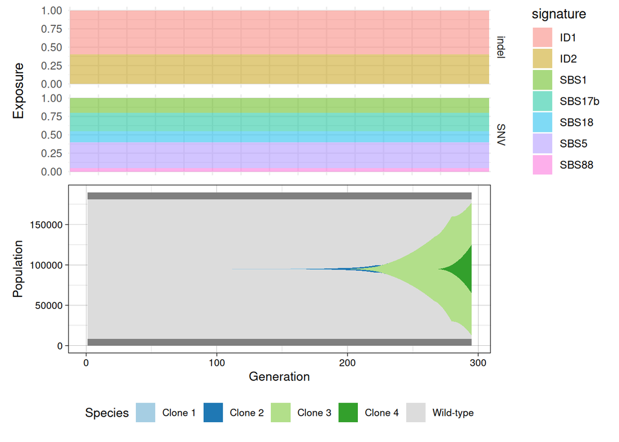

# 3 Sequencing results

The **SPN01** is sequenced with a coverage of **100**X and a simulated purity of **0.9**.